# R Notebook

# Introducción

El binge drinking, o consumo excesivo episódico de alcohol, es un problema que se presenta cuando se consume suficiente alcohol para elevar su concentración en la sangre a por lo menos 0.08 g/dl. Según el SERVICIO PAD de España, la traducción más literal del término anglosajón sería consumo “por atracón”, es decir, el consumo o ingesta de la mayor cantidad de alcohol en el menor tiempo posible. El objetivo es conseguir los efectos deseados de la sustancia, es decir, la embriaguez, de la forma más rápida. El Plan Nacional Sobre Drogas (de España) ha establecido que el binge drinking es el consumo de cinco o más bebidas en el caso de los hombres y al menos cuatro por parte de las mujeres, en el plazo de dos horas. La razón de esta diferencia, como explica Ana Ordóñez Franco, médico especializada en Adicciones y responsable del Departamento de Prevención del Instituto de Adicciones de Madrid Salud, es que las mujeres genéticamente tienen una cantidad menor de la enzima que se encarga de metabolizar el alcohol (alcohol-deshidrogenasa), lo que hace que los efectos de este en su organismo sean más intensos y duren más tiempo. Sin embargo, estos efectos también van ligados al peso de la persona y a su porcentaje de grasa corporal. Existen varios factores asociados al padecimiento de binge drinking, pero en este proyecto se buscará estudiar la posible relación que haya con la carga académica en estudiantes universitarios. El alcohol suele ser visto como una forma de relajación o de afrontar el estrés, y en el caso de muchos jóvenes, la carga académica es la principal fuente de estrés. ¿El estrés académico es, entonces, un factor asociado al binge drinking?

## Importancia

Debido a la escasa difusión del problema, el binge drinking no suele ser tomado en cuenta y las personas que lo padecen podrían minimizar las posibles consecuencias. De hecho, no suelen ser diagnosticados por un trastorno grave de consumo de alcohol. Es importante que esto deje de ser así. Los riesgos por tomar alcohol en grandes cantidades, tanto a corto como a largo plazo, son sumamente graves o hasta mortales. Desde lesiones, accidentes y caídas hasta enfermedades hepáticas, distintos tipos de cáncer, depresión, demencia y demás. Asimismo, Isabel María Martín Monzón, en su investigación “Estrés académico en estudiantes universitarios”, establece que el estrés académico también tiene graves consecuencias a corto y a largo plazo, ya que suele afectar a los estudiantes en tres planos. En el plano conductual, los jóvenes tienden a tener hábitos insalubres durante los períodos de exámenes, como consumo excesivo de cafeína, tabaco y otros estimulantes que, al ser consumidos en cantidad, pueden afectar gravemente la salud. En el plano cognitivo, los patrones emocionales y de valoración de la realidad de los estudiantes se veía afectada en las semanas previas a rendir exámenes importantes. Finalmente, en el plano psicofisiológico, puede darse una disminución de células T y de la actividad de las células “Natural Killers”, cambios que indican una depresión del sistema inmunitario. Como jóvenes universitarios, consideramos importante realizar una pequeña investigación que podría hallar una correlación entre estos dos problemas que, probablemente, estén presentes y activos en entornos cercanos a nosotros.

## Justificación

Existen numerosos estudios sobre las consecuencias del estrés académico en universitarios, pero, en América Latina, la data sobre el binge drinking y sus posibles factores asociados es escasa. Por lo que no hay estudios que evalúen si existe una correlación entre universitarios de Lima y padecimiento de binge drinking. Desde el ingreso a la universidad, los estudiantes enfrentan exigencias que, probablemente, no habían experimentado hasta entonces. De acuerdo al estudio “Executive functioning and alcohol binge drinking in university students” de María Prada et al., existe una significativa prevalencia de binge drinking en estudiantes universitarios alrededor del mundo, y se concluyó que este patrón de consumo de alcohol estaba asociado con un peor desempeño de los estudiantes. Nuestro objetivo es hallar una correlación similar a la antes mencionada en estudiantes de universidades de Lima.

# Objetivos

El objetivo de este proyecto es investigar si existe una posible relación entre el estrés académico y el Binge Drinking.

# Marco Teórico

De acuerdo a una investigación de Karina Conde et al., la incidencia de binge drinking en América Latina es de 22% de la población, superior al promedio mundial de 16%. Asimismo, según datos epidemiológicos de la Organización Mundial de la Salud (OMS), existen considerables casos de binge drinking en jóvenes de 20 a 24 años de edad. Del mismo modo, la Center for Disease Control and Prevention (CDC), hay una gran incidencia de binge drinking en los jóvenes de 18 a 34 años. Así, se puede concluir que un rango de edad bastante afectado por este patrón de consumo de alcohol son jóvenes de 18 años a más. Este patrón de consumo etílico “por atracón” se ve favorecido por el fenómeno del botellón, práctica que ha sido incorporada y normalizada ya desde hace décadas por nuestros adolescentes y jóvenes como una forma más de ocio. Tanto que, a nivel nacional, esta práctica se ha triplicado desde 2003.

## Población

La población de estudio en cuestión son los jóvenes universitarios que consumen alcohol y que podrían padecer este problema.

## Muestra

La muestra es de 194 observaciones.

## Unidad muestral

La unidad muestral son las personas (universitarios).

## Muestreo

En cuanto al proceso de muestreo, se realizó una encuesta que ha sido difundida apelando a la aleatoriedad.

## Variables

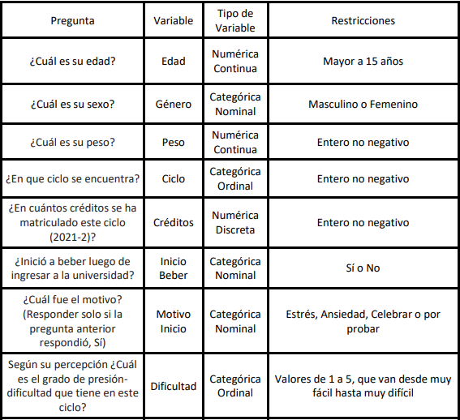

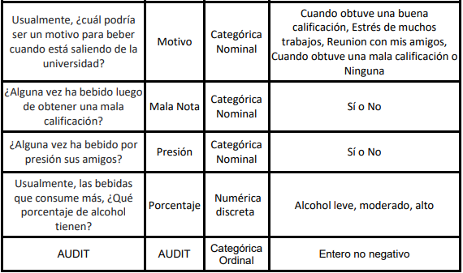

```r
library(reshape2)
```

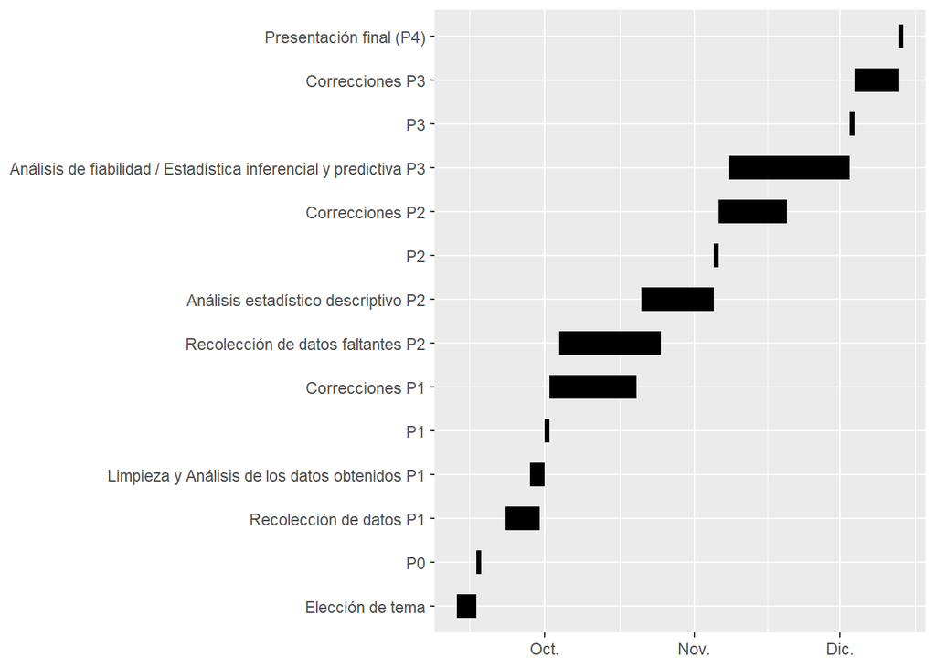

```r
library(ggplot2)
tasks <- c("Elección de tema", "P0", "Recolección de datos P1", "Limpieza y Análisis de los datos obtenidos P1", "P1",
           "Correcciones P1", "Recolección de datos faltantes P2", "Análisis estadístico descriptivo P2", "P2", "Correcciones P2",
           "Análisis de fiabilidad / Estadística inferencial y predictiva P3", "P3", "Correcciones P3", "Presentación final (P4)")
dfr <- data.frame(
  name        = factor(tasks, levels = tasks),
  start.date  = as.Date(c("2021-09-13", "2021-09-17", "2021-09-23", "2021-09-28", "2021-10-01", "2021-10-02", "2021-10-04",
                          "2021-10-21", "2021-11-05", "2021-11-06", "2021-11-08", "2021-12-03", "2021-12-04", "2021-12-13")),
  end.date    = as.Date(c("2021-09-17", "2021-09-18", "2021-09-30", "2021-10-01", "2021-10-02", "2021-10-20", "2021-10-25",
                          "2021-11-05", "2021-11-06", "2021-11-20", "2021-12-03", "2021-12-04", "2021-12-13", "2021-12-14"))
)
mdfr <- melt(dfr, measure.vars = c("start.date", "end.date"))
ggplot(mdfr, aes(value, name)) +
  geom_line(size = 6) +
  xlab(NULL) +
  ylab(NULL)
```

```r
library(readr)
library(dplyr)
```

# LEEMOS EL ARCHIVO .CSV

```r
DF <- read_csv("Binge drinking.csv")
```

# DEFINIMOS VARIABLES

```r
DF %>% rename(
 Datetime = `Marca temporal`
  , Edad = `¿Qué edad tienes?`
  , Sexo = Sexo
  , Peso = `¿Cuál es su peso? (en Kg)`
  , Ciclo = `¿En qué ciclo se encuentra?`
  , Creditos = `¿En cuántos créditos se ha matriculado este ciclo (2021-2)?`
  , Examenesjalados = `¿Cuántas evaluaciones desaprobó durante el presente ciclo (2021-2)?`
  , Dificultad = `Según su percepción ¿Cuál es el grado de presión-dificultad que tiene en este ciclo?`
  , InicioBeber = `¿Inició a beber luego de ingresar a la universidad?`
  , MotivoInicio = `¿Cuál fue el motivo? (Responder solo si la pregunta anterior respondió, Sí)`
  , Motivo = `Usualmente, ¿cuál podría ser un motivo para beber cuando está saliendo de la universidad?`
  , MalaNota =`¿Alguna vez ha bebido luego de obtener una mala calificación?`
  , Presion = `¿Alguna vez ha bebido por presión de sus amigos?`
  , Porcentaje = `Usualmente, las bebidas que consume más, ¿Qué porcentaje de alcohol tienen?`
  , AUDIT1 = `Completa con sinceridad el siguiente test: [¿Qué tan seguido consume bebidas alcohólicas?]`
  , AUDIT2 = `Completa con sinceridad el siguiente test: [¿Cada cuánto consume 6 o más bebidas en una sola ocasión?]`
  , AUDIT3 = `Completa con sinceridad el siguiente test: [En el último año, ¿cada cuánto sintió que no pudo parar de tomar luego de haber empezado?]`
  , AUDIT4 = `Completa con sinceridad el siguiente test: [En el último año, ¿cada cuánto dejó de hacer lo que debía por tomar bebidas alcohólicas?]`
  , AUDIT5 = `Completa con sinceridad el siguiente test: [¿Con qué frecuencia durante el último año ha necesitado un primer trago por la mañana para empezar después de una sesión de bebida en exceso?]`
  , AUDIT6 = `Completa con sinceridad el siguiente test: [En el último año, ¿cada cuánto sintió culpa o remordimiento luego de tomar bebidas alcohólicas?]`
  , AUDIT7 = `Completa con sinceridad el siguiente test: [¿Con qué frecuencia durante el último año ha estado incapaz de recordar lo que pasó la noche antes porque habías estado bebiendo?]`
  , AUDIT8 = `En un día típico cuando bebe, ¿Cuántas bebidas que contienen alcohol toma?`
  , AUDIT9 = `¿Usted o alguien más ha sido lesionado como resultado de su bebida?`
  , AUDIT10 = `¿Tiene algún familiar, amigo, médico u otro que haya estado preocupado por su consumo de alcohol o le ha sugerido que deje de beber?`
  ) -> DFN

rm(DF)

DF <- DFN

rm(DFN)
```

Esta función convierte las preguntas del AUDIT que se encuentran en el DF actual a un puntaje, basándose en el cuestionario original:

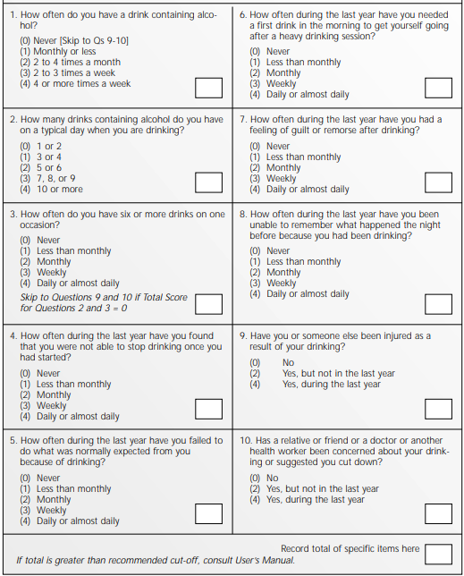

Luego se eliminan las columnas de las 10 preguntas y se agrega una nueva columna con los resultados de cada observación.

```r
audit <- function (DF) {
  puntajes <- c()
  for (i in 1:nrow(DF)) {
    suma <- 0
    for (j in 14:ncol(DF)) {
      if (DF[i, j] == "Nunca" | DF[i, j] == "1 o 2" | DF[i, j] == "no suelo beber" | DF[i, j] == "No") {
      suma <- suma + 0
      } else if (DF[i, j] == "1 vez al mes o menos" | DF[i, j] == "3 o 4") {
        suma <- suma + 1
      } else if (DF[i, j] == "2 a 4 veces al mes" | DF[i, j] == "5 o 6" | DF[i, j] == "Sí, pero no en el último año") {
        suma <- suma + 2
      } else if (DF[i, j] == "2 a 3 veces por semana" | DF[i, j] == "7, 8 o 9") {
        suma <- suma + 3
      } else if (DF[i, j] == "4 o más veces por semana" | DF[i, j] == "10 o más" | DF[i, j] == "Sí, durante el último año") {
        suma <- suma + 4
      }
    }
    puntajes <- append(puntajes, suma)
  }
  return(puntajes)
}

AUDIT <- audit(DF)

DF$AUDIT1 <- NULL
DF$AUDIT2 <- NULL
DF$AUDIT3 <- NULL
DF$AUDIT4 <- NULL
DF$AUDIT5 <- NULL
DF$AUDIT6 <- NULL
DF$AUDIT7 <- NULL
DF$AUDIT9 <- NULL
DF$AUDIT10 <- NULL

DF$AUDIT <- AUDIT
```

El puntaje obtenido por el AUDIT se mide de la siguiente manera:

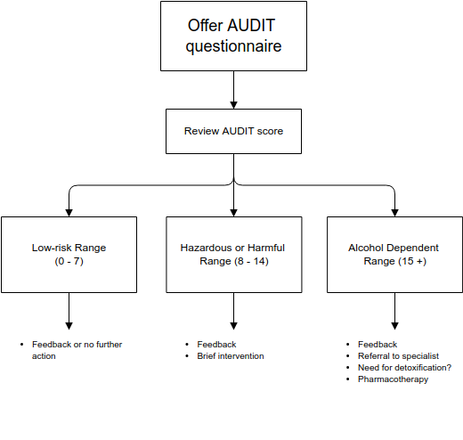

## Arreglamos una variable

```r
DF %>% mutate(Cantbebidas_regresion = AUDIT8) ->DF
n <- sum(DF$Cantbebidas_regresion == "no suelo beber")
DF$Cantbebidas_regresion[DF$Cantbebidas_regresion == "no suelo beber"] <- runif(n,0,1)
n <- sum(DF$Cantbebidas_regresion == "1 o 2")
DF$Cantbebidas_regresion[DF$Cantbebidas_regresion == "1 o 2"] <- runif(n, 1, 2.5)
n <- sum(DF$Cantbebidas_regresion == "3 o 4")
DF$Cantbebidas_regresion[DF$Cantbebidas_regresion == "3 o 4"] <- runif(n, 2.5, 4.5)
n <- sum(DF$Cantbebidas_regresion == "5 o 6")
DF$Cantbebidas_regresion[DF$Cantbebidas_regresion == "5 o 6"] <- runif(n, 4.5, 6.5)
n <- sum(DF$Cantbebidas_regresion == "7, 8 o 9")
DF$Cantbebidas_regresion[DF$Cantbebidas_regresion == "7, 8 o 9"] <- runif(n, 6.5, 9.5)
n <- sum(DF$Cantbebidas_regresion == "10 o más")
DF$Cantbebidas_regresion[DF$Cantbebidas_regresion == "10 o más"] <-runif(n, 9.5, 12)
DF$Cantbebidas_regresion <- as.numeric(DF$Cantbebidas_regresion)
```

```r
DF %>% mutate(Cantbebidas = AUDIT8) ->DF
DF$Cantbebidas[DF$Cantbebidas == "no suelo beber"] <-(0+1)/2
DF$Cantbebidas[DF$Cantbebidas == "1 o 2"] <- (1 + 2.5)/2
DF$Cantbebidas[DF$Cantbebidas == "3 o 4"] <- (2.5 + 4.5)/2
DF$Cantbebidas[DF$Cantbebidas == "5 o 6"] <- (4.5 + 6.5)/2
DF$Cantbebidas[DF$Cantbebidas == "7, 8 o 9"] <- (6.5 + 9.5)/2
DF$Cantbebidas[DF$Cantbebidas == "10 o más"] <-(9.5 + 12)/2
DF$Cantbebidas<- as.numeric(DF$Cantbebidas)
DF$AUDIT8 <- NULL
```

```r
 DF$Ciclo[(DF$Ciclo == "primer ciclo")] <- 1
 DF$Ciclo[(DF$Ciclo == "segundo ciclo")] <- 2
 DF$Ciclo[(DF$Ciclo == "tercer ciclo")] <- 3
 DF$Ciclo[(DF$Ciclo == "cuarto ciclo")] <- 4
 DF$Ciclo[(DF$Ciclo == "quinto ciclo")] <- 5
 DF$Ciclo[(DF$Ciclo == "sexto ciclo")] <- 6
 DF$Ciclo[(DF$Ciclo == "séptimo ciclo")] <- 7
 DF$Ciclo[(DF$Ciclo == "octavo ciclo")] <- 8
 DF$Ciclo[(DF$Ciclo == "noveno ciclo")] <- 9
 DF$Ciclo[(DF$Ciclo == "décimo ciclo o más")] <- 10
 DF$Ciclo <- as.numeric(DF$Ciclo)
```

Modificamos la variable ciclo, ya que por un error nuestro lo pusimos como string, cuando tenía que ser número.

```r
DF$Porcentaje[DF$Porcentaje == "8° - 12° (Bajo)"] <- 10
DF$Porcentaje[DF$Porcentaje == "17° - 25° (Moderado)"] <- 21
DF$Porcentaje[DF$Porcentaje == "40° - 45° (Alto)"] <- 42.5
DF$Porcentaje[DF$Porcentaje == "No consumo bebidas alcoholicas"] <- 0
DF$Porcentaje <- as.numeric(DF$Porcentaje)

DF$Porcentaje_categorica <- DF$Porcentaje

DF %>% mutate(Porcentaje_categorica = (cut(DF$Porcentaje, breaks = c(-Inf,15,25,45), labels = c("Bajo", "Medio", "Alto"), ordered_result = TRUE))) -> DF
```

### Observación

Creamos la variable “Porcentaje_categorica” con la intención de, valga la redundancia, categorizar los porcentajes de consumo de alcohol en 3 grupos, en lugar de solo contar con los valores 10, 21 y 42.5. Los grupos se formaron de la siguiente manera:

- 10 -> “Bajo”
- 21 -> “Medio”
- 42.5 -> “Alto”

```r
DF$Creditos[DF$Creditos == "No me acuerdo :c"] <- NA
DF$Creditos[DF$Creditos == 20.5] <- NA
DF$Creditos[DF$Creditos > 29] <- NA
DF$Creditos[DF$Creditos == 0] <- NA
DF$Creditos <- as.numeric(DF$Creditos)
```

```r
DF$Examenesjalados <- as.numeric(DF$Examenesjalados)
```

Transformamos la variable exámenes jalados a numérica, ya que un encuestado respondió con palabras.

```r
DF$Peso[(DF$Peso == "50kg")] <- 50
DF$Peso[(DF$Peso == "60 kg")] <- 60
DF$Peso[(DF$Peso == "70 kilogramos")] <- 70
DF$Peso <- as.numeric(DF$Peso)
DF$Peso[(DF$Peso <= 35)] <- NA
```

Limpiamos y arreglamos la variable peso, ya que encontramos valores anómalos como 20 (kg) y algunos encuestados pusieron “kg” o “kilogramos”.

```r
DF<- DF[DF$Porcentaje!=0, ]
```

```r
DF$Datetime <- NULL
DF$MotivoInicio <- NULL
DF$Motivo <- NULL
DF$Presion <- NULL
```

Eliminamos las siguientes variables debido a que los estudios causales son difíciles de demostrar.

```r
DF %>% mutate(Riesgo = (cut(DF$AUDIT, breaks = c(-Inf,0,7,14,Inf), labels = c("Nulo", "Bajo", "Medio", "Alto"), ordered_result = TRUE))) -> DF
```

### Observación

Creamos la variable riesgo con el fin de categorizar los puntajes del AUDIT. Los valores que toma cada nivel son: - 0 -> Nulo - 1 a 7 -> Bajo - 8 a 14 -> Medio - 15 a más -> Alto

# Descriptores Numéricos

## 1) Edad

Con esta variable nos aseguraremos que nuestro público objetivo sean estudiantes universitarios, por lo cual estudiaremos descriptores numéricos como: la moda, mediana y la media, de la edad de los encuestados. Mediante un histograma.

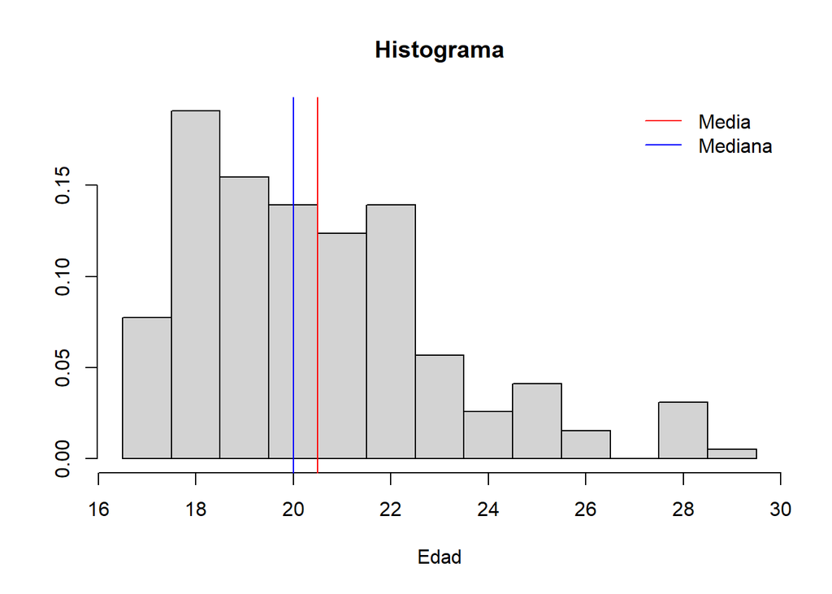

```r
hist(DF$Edad, breaks = (min(DF$Edad):(max(DF$Edad) + 1)) - 0.5, main = "Histograma", xlab = "Edad", ylab = "", prob=TRUE)

abline(v = c(mean(DF$Edad, na.rm = TRUE), median(DF$Edad, na.rm = TRUE)), col = c("red", "blue"))
legend("topright"
       , legend = c("Media", "Mediana")
       , lty = 1
       , col = c("red", "blue")
       , bty = "n"
       )
```

### Análisis:

El análisis correspondiente a esta variable “Edad” tendrá como objetivo principal corroborar que nuestra encuesta fue realizada a personas pertenecientes a nuestro público objetivo como los son los estudiantes universitarios.

### Moda:

Observamos que la moda es de 18 años, que corresponde al dato más solicitado por nuestros encuestados.

### Mediana:

En la variable “Edad” nuestra mediana es de 20, la cual corresponde a la edad que se ubica al medio de los datos ordenados.

### Promedio:

Apreciamos que la media o promedio de esta variable es de 20.5 años, la cual es una edad sensata para ubicarse en el proceso de formación universitaria.

Aparte de ello podemos ver que la media está a la derecha por lo que inferimos que los datos están sesgados a la derecha.

## 2) Peso

Con el peso se busca analizar las posibles consecuencias de un consumo inadecuado del alcohol en un estudiante universitario, pues mientras mayor sea el peso de la persona, peores serían las consecuencias físicas.

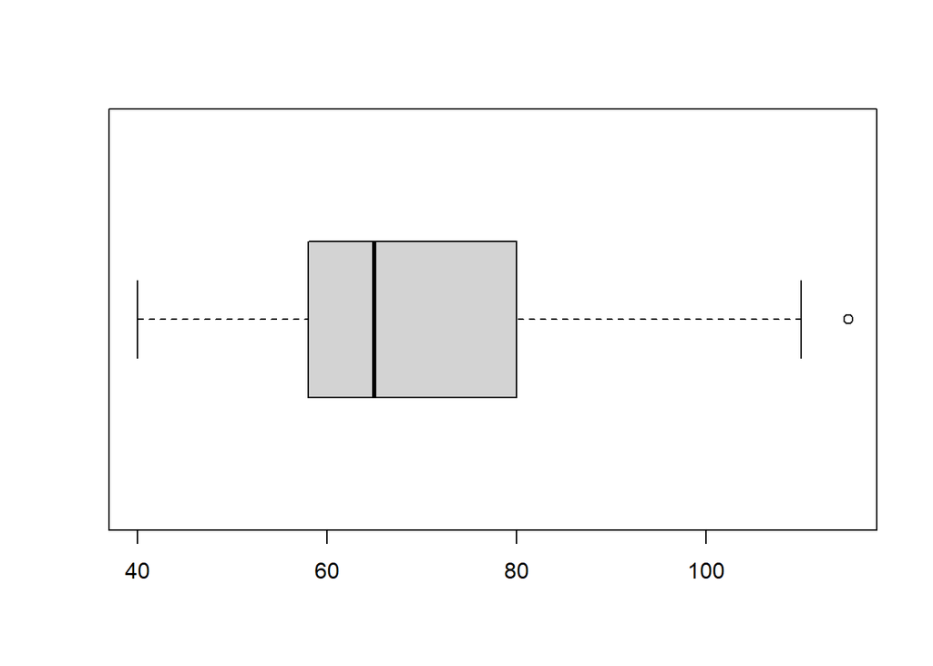

```r
boxplot(DF$Peso, horizontal = TRUE)
```

```r
cat("Promedio:", mean(DF$Peso, na.rm = TRUE), "\n")
```

```
## Promedio: 68.94503
```

```r
cat("mediana:", median(DF$Peso, na.rm = TRUE), "\n")
```

```
## mediana: 65
```

```r
cat("Desviación estándar:", sd(DF$Peso, na.rm = TRUE), "\n")
```

```
## Desviación estándar: 15.06262
```

```r
cat("Rango:"
    , max(DF$Peso, na.rm = TRUE) - min(DF$Peso, na.rm = TRUE)
    , "\n"
    )
```

```
## Rango: 75
```

```r
cat("Rango intercuartil:"
    , quantile(DF$Peso, 0.75, na.rm = TRUE)
    - quantile(DF$Peso, 0.25, na.rm = TRUE)
    , "\n"
    )
```

```
## Rango intercuartil: 22
```

```r
cat("mínimo:", min(DF$Peso, na.rm = TRUE), "\n")
```

```
## mínimo: 40
```

```r
cat("máximo:", max(DF$Peso, na.rm = TRUE), "\n")
```

```
## máximo: 115
```

### Análisis:

En este caso graficamos un boxplot debido a los datos diversos con los que contamos, las cuales serán explicados a continuación:

### Promedio

El promedio correspondiente a esta variable es de 68.945 Kg, la cual subjetivamente es un peso que puede considerarse como la media del peso entre estudiantes universitarios, teniendo en cuenta que encuestamos a hombres (suelen tener un peso mayor que las mujeres) y mujeres (suelen tener un peso menor que los hombres).

### Mediana

La mediana es de 65 Kg y considerando al promedio que es mayor se puede deducir que nuestros datos correspondientes a esta variable están sesgados a la derecha de una línea numérica.

### Desviación estándar

La desviación estándar es de 15.06 Kg, esto nos quiere decir que nuestros datos se encuentran relativamente dispersos.

### Rango

Existe una diferencia de 75Kg entre nuestro máximo y mínimo dato de peso (115 y 40 Kg respectivamente).

### Rango intercuartil

Existe una diferencia de 22 Kg entre el primer y tercer cuartil.

## 3) Ciclo

Hacemos un histograma para la variable categórica ciclo, debido a que averiguaremos el estrés académico mientras el estudiante vive la etapa universitaria.

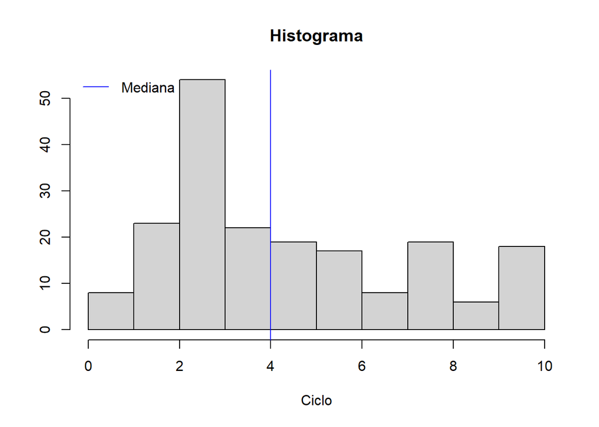

```r
hist(DF$Ciclo, breaks=0:10, main = "Histograma", xlab = "Ciclo", ylab = "")
abline(v = c(median(DF$Ciclo, na.rm = TRUE)), col = c("blue"))
legend("topleft"
       , legend = c("Mediana")
       , lty = 1
       , col = c("blue")
       , bty = "n"
       )
```

### Análisis:

Este histograma nos servirá notablemente para ver los descriptores numéricos que se le puede atribuir a una variable categórica ordinal (moda y mediana), como el ciclo que los estudiantes universitarios encuestados se encuentran cursando.

### Moda

Claramente en nuestra encuesta participaron más estudiantes del tercer ciclo, con más de 50 participaciones.

### Mediana

La mediana correspondiente a esta variable es el cuarto ciclo, la cual básicamente habla de una diversidad de nuestros datos, ya que se encuentra muy cerca al quinto ciclo (mitad de la vida universitaria).

### 4) Exámenes Jalados

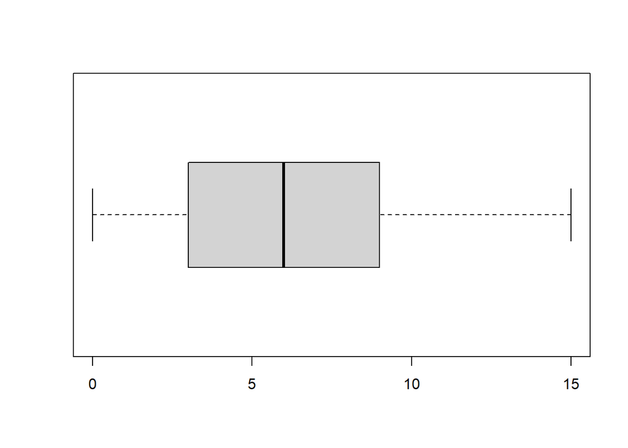

```r
boxplot(DF$Examenesjalados, horizontal = TRUE)
```

```r
cat("Promedio:", mean(DF$Examenesjalados, na.rm = TRUE), "\n")
```

```
## Promedio: 6.105263
```

```r
cat("mediana:", median(DF$Examenesjalados, na.rm = TRUE), "\n")
```

```
## mediana: 6
```

```r
cat("Desviación estándar:", sd(DF$Examenesjalados, na.rm = TRUE), "\n")
```

```
## Desviación estándar: 3.871527
```

```r
cat("Rango:"
    , max(DF$Examenesjalados, na.rm = TRUE) - min(DF$Examenesjalados, na.rm = TRUE)
    , "\n"
    )
```

```
## Rango: 15
```

```r
cat("Rango intercuartil:"
    , quantile(DF$Examenesjalados, 0.75, na.rm = TRUE)
    - quantile(DF$Examenesjalados, 0.25, na.rm = TRUE)
    , "\n"
    )
```

```
## Rango intercuartil: 6
```

```r
cat("mínimo:", min(DF$Examenesjalados, na.rm = TRUE), "\n")
```

```
## mínimo: 0
```

```r
cat("máximo:", max(DF$Examenesjalados, na.rm = TRUE), "\n")
```

```
## máximo: 15
```

## Análisis:

Analizando el gráfico mostrado nos damos cuenta que nos existen datos atípicos, cabe resaltar que esta variable solo cuenta con 57 observaciones, por lo que la presencia de estos casos atípicos es menos probable. # Promedio

El promedio en esta variable es 6.105263 evaluaciones desaprobadas

# Mediana

La mediana es de 6 lo cual nos indica que al menos la mitad de los estudiantes encuestados han desaprobado 6 o mas exámenes y comparándolo con el promedio que es mayor se puede deducir que nuestros datos correspondientes a esta variable están sesgados a la derecha de una línea numérica.

# Desviación estándar

La desviación estándar es de 3.871527, esto nos quiere decir que nuestros datos se encuentran relativamente dispersos.

# Descriptores Gráficos

## 1) Créditos - dificultad

Buscaremos una relación entre la dificultad del ciclo y la cantidad de créditos que cursa un estudiante universitario, para así relacionarlo con las causas de ingerir bebidas alcohólicas.

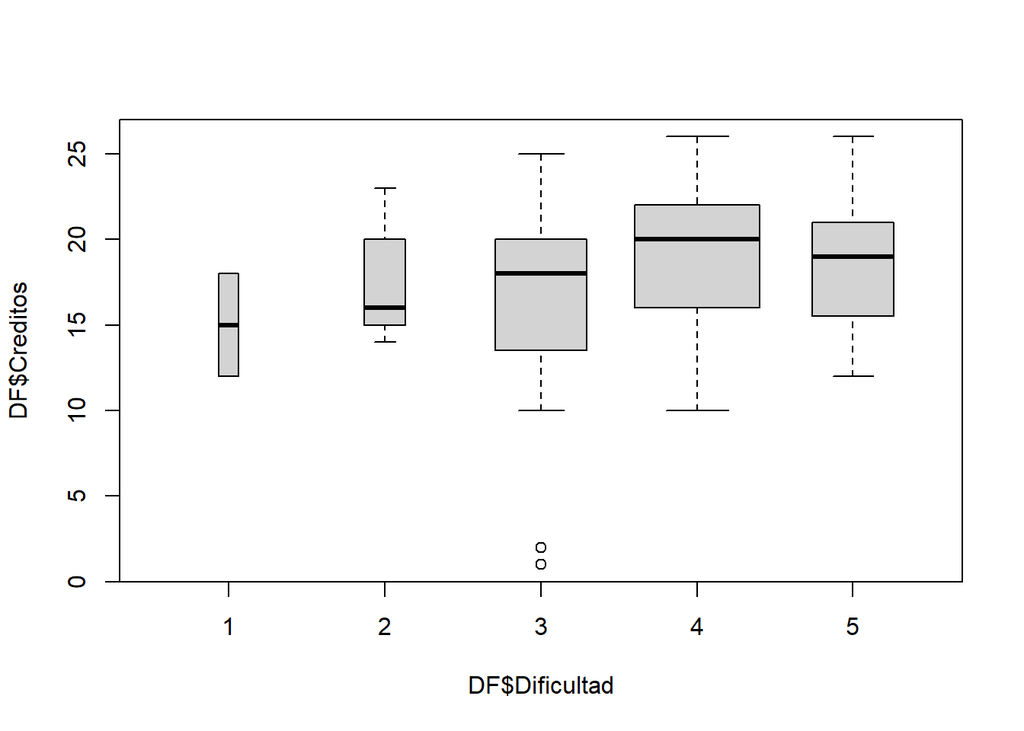

```r
boxplot(DF$Creditos ~ DF$Dificultad, varwidth = TRUE, na.rm=TRUE)
```

### Análisis:

Podemos verificar una tendencia evidente que planteamos con respecto a variables de tipo estrés académico, ya que se nota que mientras la cantidad de créditos académicos aumenta, la dificultad del ciclo también.

## 2) Créditos - Nivel de Riesgo

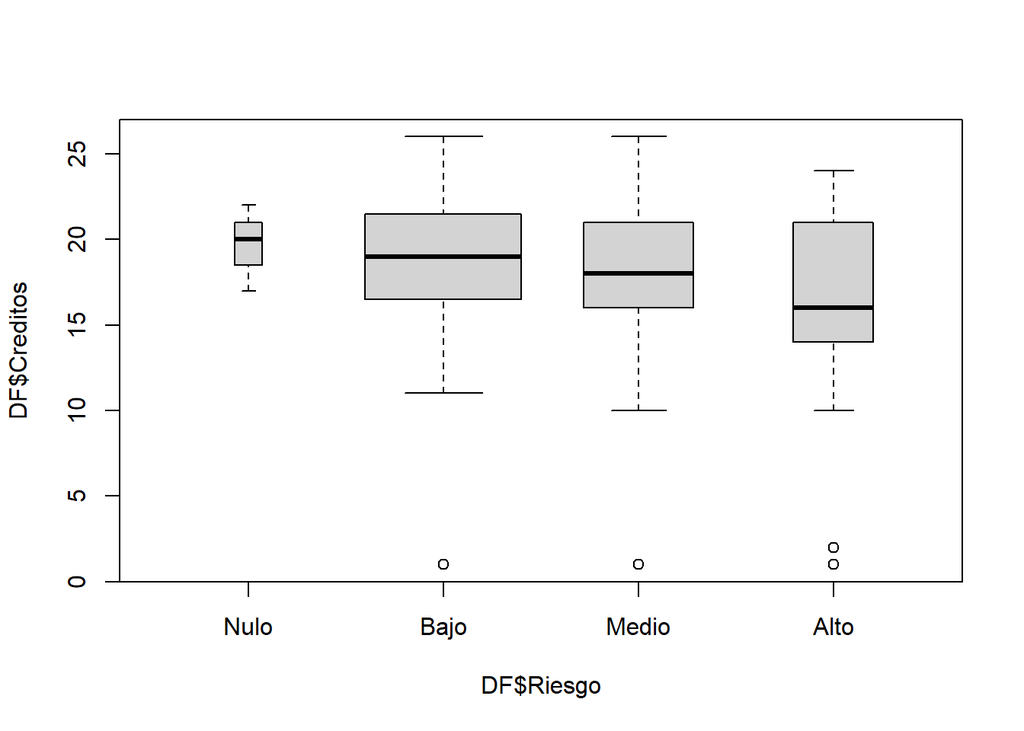

```r
boxplot(DF$Creditos ~ DF$Riesgo, varwidth = TRUE)
```

### Análisis:

Realizamos un boxplot indexado para la comparativa de una variable categórica y una numérica. Vemos que los de riesgo nulo llevan de 17 a 22 créditos, bajo tiene un rango de 11 a 26 créditos y que el riesgo medio esta concentrado en el rango de 10 a 26 créditos, riesgo alto de 10 a 24.

## 3) Porcentaje de alcohol - Edad

Analizaremos, mediante la gráfica, cuál es la relación entre la edad de la persona y el porcentaje de alcohol que consume.

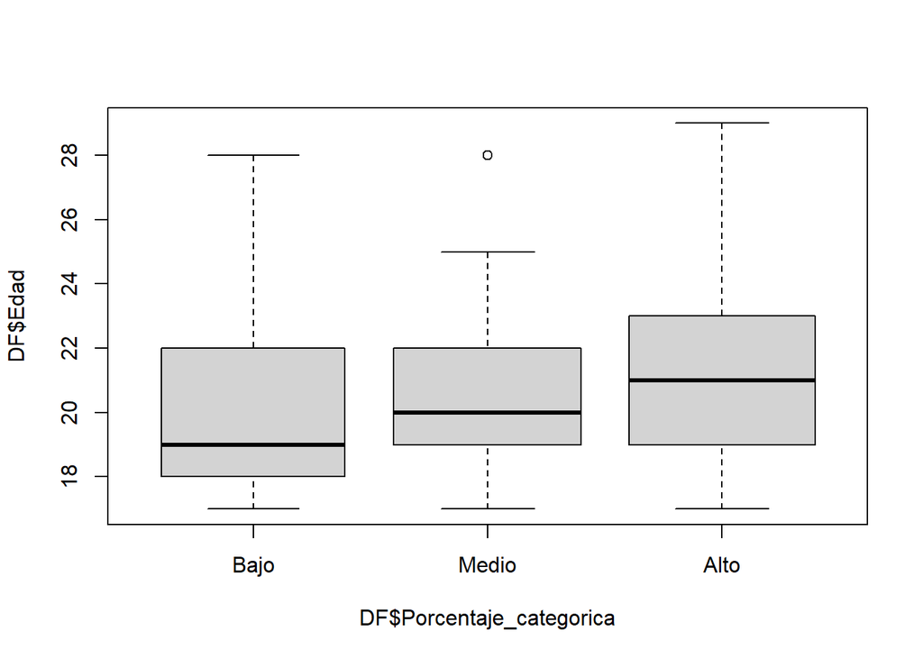

```r
boxplot(DF$Edad ~ DF$Porcentaje_categorica, varwidth=TRUE)
```

### Análisis:

Es interesante y es un resultado que esperábamos. Las personas de más edad suelen tomar bebidas con mayor porcentaje de alcohol, y las personas con menor edad consumen bebidas con menos porcentajes de alcohol exceptuando los datos atípicos.

## 4) Grado de Dificultad del ciclo - Puntaje del AUDIT

El AUDIT se usa para medir el nivel de riesgo que presenta el consumo de alcohol de una persona. En esta gráfica se busca ver la relación entre la dificultad y los resultados del mencionado test.

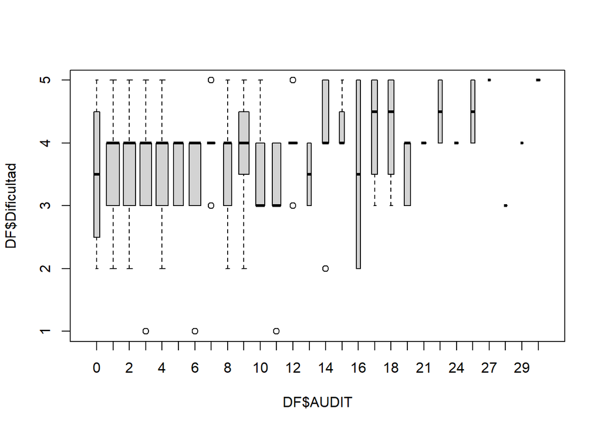

```r
boxplot(DF$Dificultad ~ DF$AUDIT, varwidth =TRUE)
```

## 5) Porcentaje de alcohol - Puntaje del AUDIT

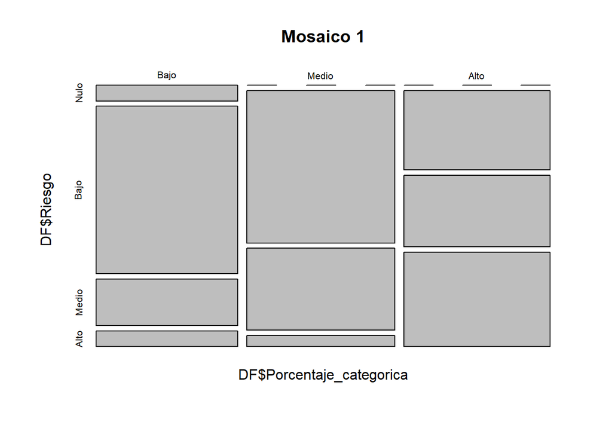

```r
mosaicplot(DF$Porcentaje_categorica ~ DF$Riesgo, main = "Mosaico 1")
```

### Análisis:

Es posible notar que solo los que tienen un nivel de porcentaje bajo pueden tener riesgo nulo. También se puede apreciar que los que consumen un porcentaje alto de alcohol tiene mayor riesgo de padecer Binge Drinking.

## 6) Sexo - ¿Inició a beber luego de ingresar a la Universidad?

En la siguiente gráfica, buscamos averiguar si el sexo de la persona influye en la decisión de iniciar a beber en la universidad.

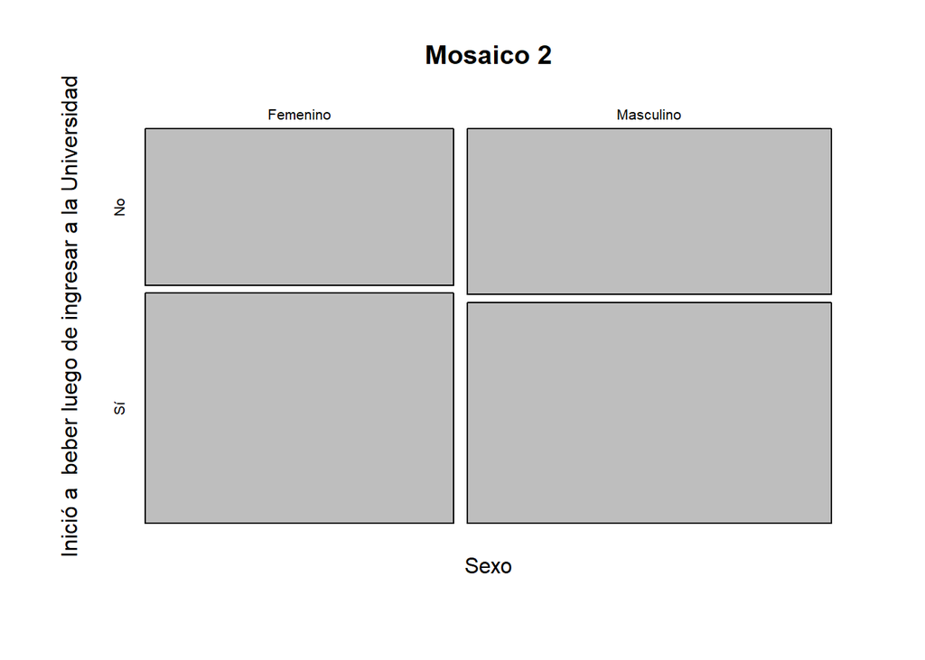

```r
mosaicplot(DF$Sexo~DF$InicioBeber, main="Mosaico 2", xlab = "Sexo", ylab = "Inició a  beber luego de ingresar a la Universidad")
```

### Análisis:

En este gráfico se aprecia notablemente que, en nuestra muestra, no hay diferencia de géneros entre personas que han iniciado a beber luego de haber ingresado a la universidad.

## 7) Sexo - Nivel de riesgo

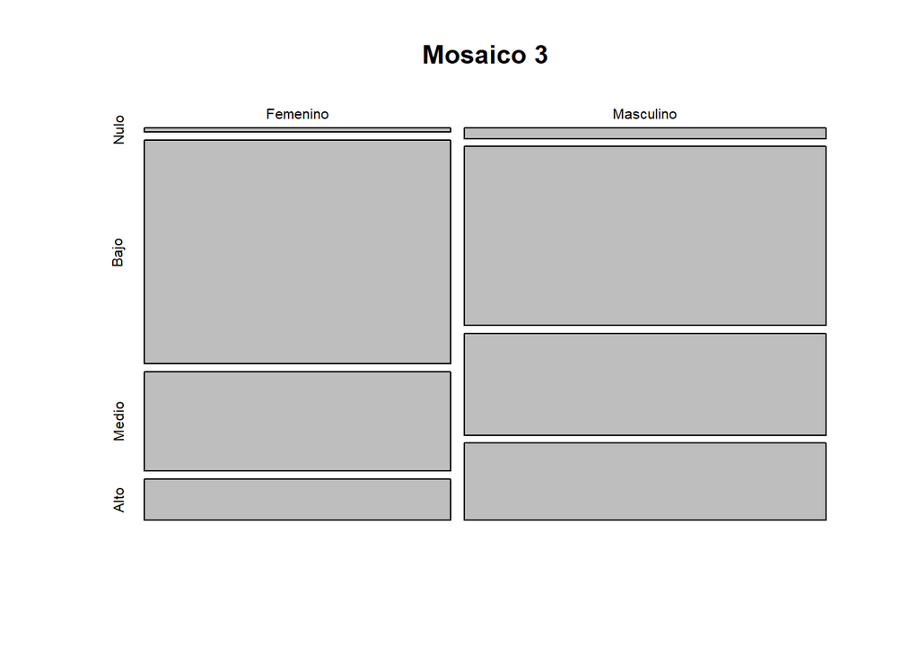

```r
mosaicplot(table(DF$Sexo, DF$Riesgo), main="Mosaico 3")
```

Sumando este gráfico al anterior, es notorio que hay más mujeres con riesgo bajo de padecer de Binge Drinking, mientras que los hombres, en comparación a las mujeres, se encontrarían con un mayor riesgo de padecer de Binge Drinking.

## 8) Porcentaje de estudiantes que iniciaron a beber después de haber ingresado a la Universidad

En este *pie chart*, se observa el porcentaje de personas que tienden a consumir alcohol luego de ingresar a la universidad, lo cual luego nos llevará a ver si eso se debe a malas calificaciones o no.

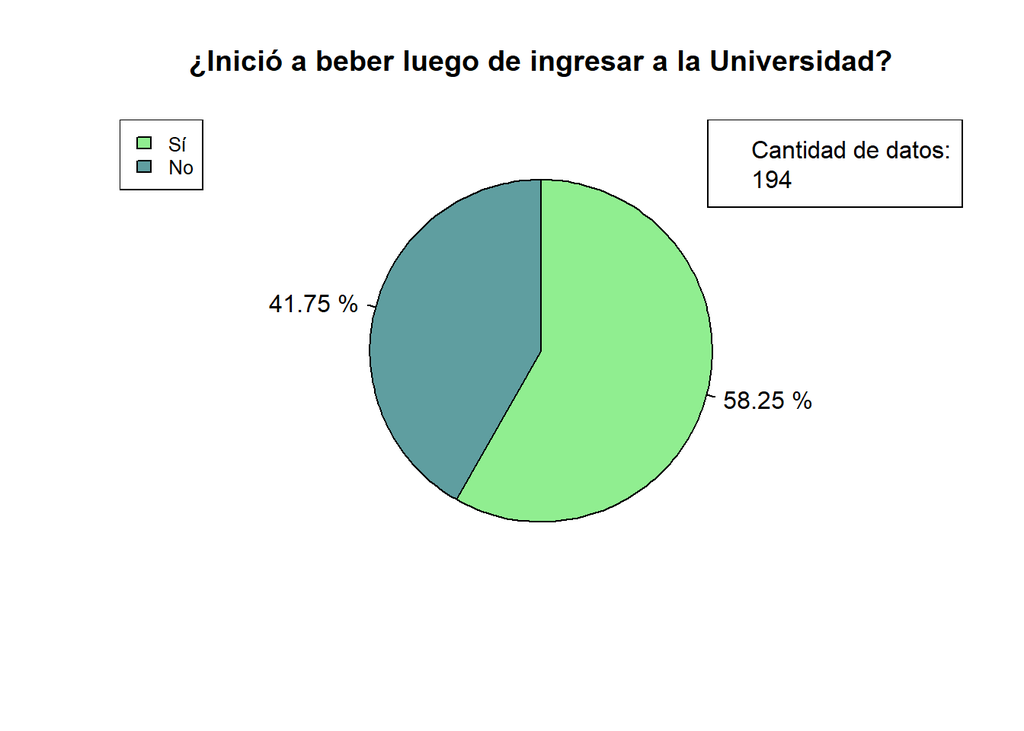

```r
m<- c(round((sum((DF$InicioBeber=="Sí"))/sum(table(DF$InicioBeber)))*100,2),round((sum((DF$InicioBeber=="No"))/sum(table(DF$InicioBeber)))*100,2))
label <- paste(m, "%", sep=" ")
color <- c("lightgreen", "cadetblue")
pie(m, labels = label, clockwise = TRUE, col = color, main = "¿Inició a beber luego de ingresar a la Universidad?")
legend("topleft",legend = c("Sí", "No"), cex=0.8, fill = color)
legend("topright",legend =c("Cantidad de datos:", nrow(DF)) )
```

### Análisis:

Es importante señalar que la mayoría respondió sí, ya que usualmente los alumnos universitarios ya cumplen con la mayoría de edad y al participar en reuniones o fiestas pueden haber iniciado a consumir por influencia de sus amistades o por estrés.

## 9) ¿Inició a beber luego de obtener malas calificaciones?

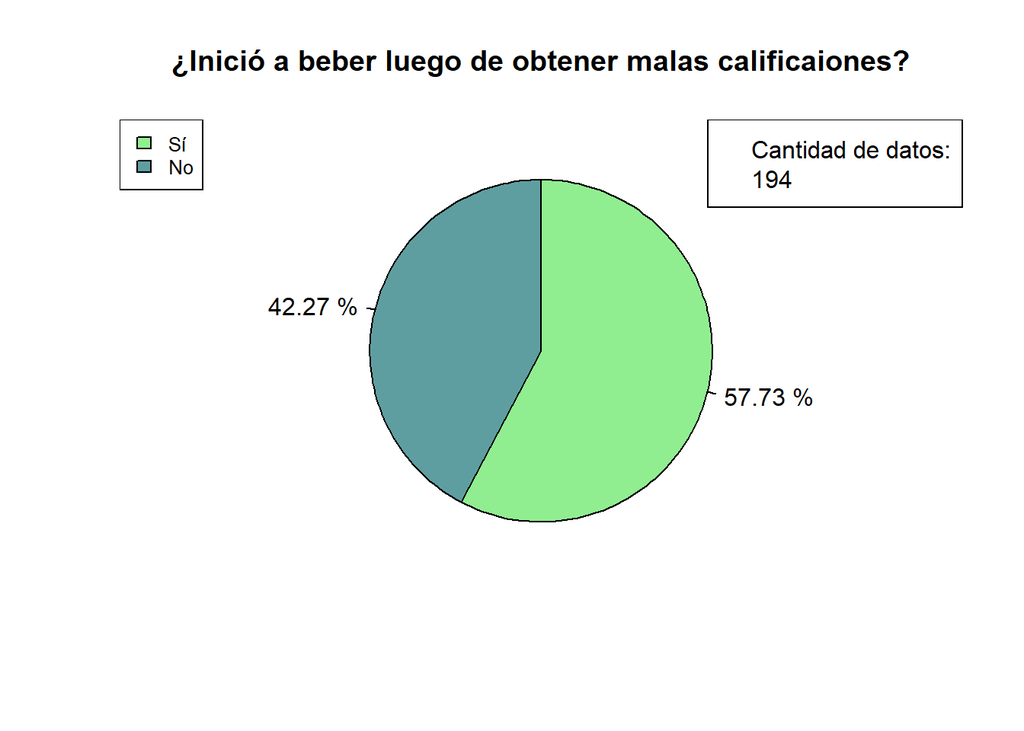

```r
m<- c(round((sum((DF$MalaNota=="Sí"))/sum(table(DF$MalaNota)))*100,2),round((sum((DF$MalaNota=="No"))/sum(table(DF$MalaNota)))*100,2))
label <- paste(m, "%", sep=" ")
color <- c("lightgreen", "cadetblue")
pie(m, labels = label, clockwise = TRUE, col = color, main = "¿Inició a beber luego de obtener malas calificaiones?")
legend("topleft",legend = c("Sí", "No"), cex=0.8, fill = color)
legend("topright",legend =c("Cantidad de datos:", nrow(DF)) )
```

### Análisis:

Aunque “sí” es la respuesta más usada, tomamos que existe una ligera diferencia con el “no”, lo cual indicaría que uno de los motivos más importantes por el cual alguien puede llegar a beber es, efectivamente, obtener malas calificaciones en un examen.

# Patrones

## Cantidad de bebidas vs Exámenes jalados

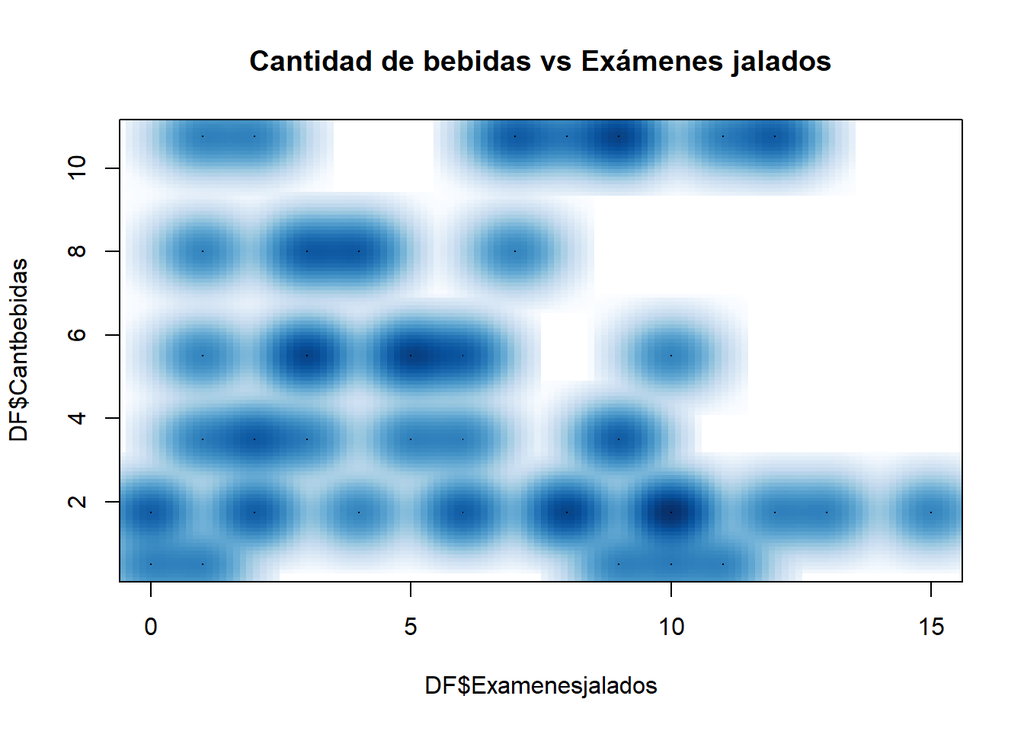

```r
smoothScatter(DF$Cantbebidas ~ DF$Examenesjalados, main="Cantidad de bebidas vs Exámenes jalados")
```

```r
cor(DF$Cantbebidas, DF$Examenesjalados, use = "complete.obs")
```

```
## [1] 0.01688907
```

En primer lugar, buscamos relacionar variables correspondientes al consumo excesivo de alcohol (Binge drinking) y el estrés académico mediante la siguiente lógica:

Estrés académico ——–> Evaluaciones jaladas

Binge drinking ——–> Cantidad de bebidas ingeridas con normalidad

En segundo lugar, realizamos el análisis correspondiente al plot y la correlación entre estas dos variables numéricas para poder responder a nuestro objetivo: saber si el estrés académico es un factor asociado al Binge drinking. En NUESTRA MUESTRA podemos objetar que no existe una relación directa entre estás dos variables debido a que nos arroja una correlación muy cercana a 0 y una gráfica muy dispersa.

## Porcentaje de alcohol vs créditos

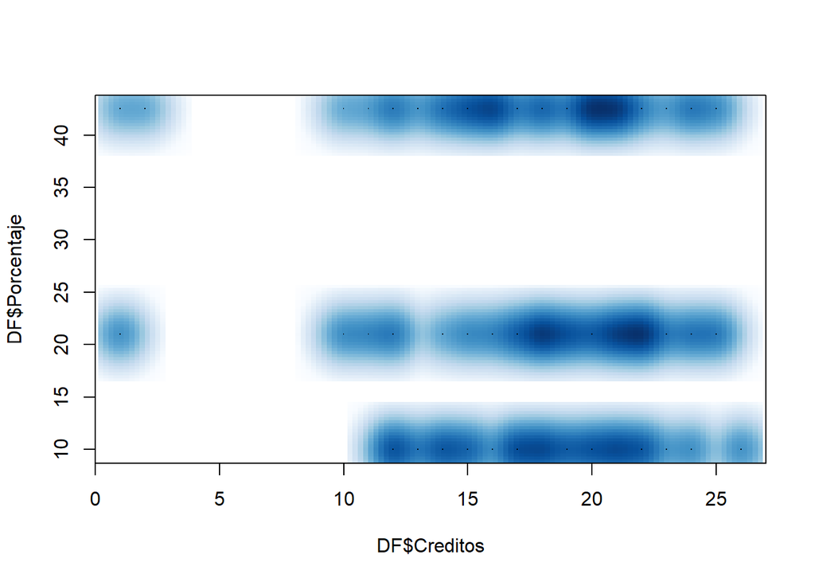

```r
smoothScatter(DF$Porcentaje ~ DF$Creditos)
```

```r
cor(DF$Porcentaje, DF$Creditos, use = "complete.obs")
```

```
## [1] -0.04826445
```

**Análisis**

En línea con nuestra hipótesis inicial, la cual era que existía cierta relación entre el estrés académico y el padecimiento de Binge Drinking, decidimos comparar la variable “Créditos” como un indicador de estrés académico a la que están sometidos los estudiantes y la variable “Porcentaje”. En principio, el resultado que esperábamos era una correlación de por lo menos 0.3, lo cual nos mostraría que hay una relación. En cambio, el resultado obtenido fue una correlación de -0.04826445 indicándonos que en nuestra muestra no existe una relación estrecha entre estas.

## Cantidad de bebidas vs Peso:

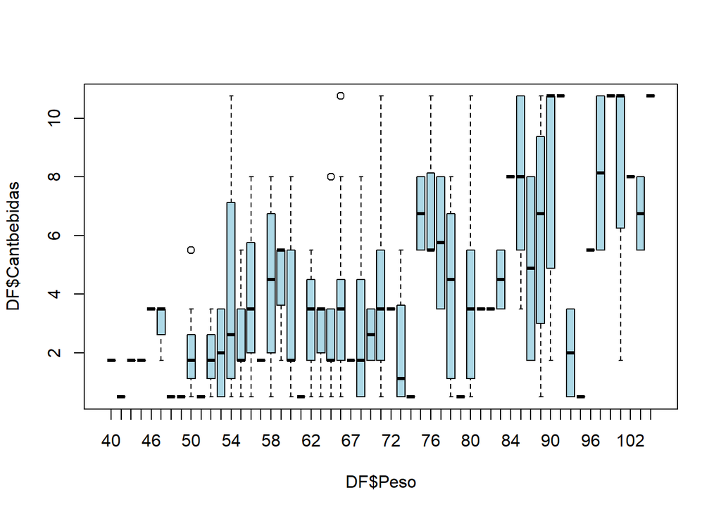

```r
boxplot(DF$Cantbebidas ~ DF$Peso, col= "lightblue")
```

```r
cor(DF$Cantbebidas, DF$Peso, use = "complete.obs")
```

```
## [1] 0.4753213
```

Podemos ver que la relación entre “cantidad de bebidas” y “peso”, es moderada, con una correlación de 0.475. A medida que aumenta el peso, la cantidad que bebe la persona aumenta. Esto es gracias a que el peso es uno de los factores que permite consumir más cantidad alcohol, a mayor peso también hay mayor cantidad de agua en el organismo que permite diluir más rápido el alcohol. Es por esto que en dos personas de diferente peso que consuman la misma cantidad de bebidas, la que tiene mayor peso tendrá menor concentración de alcohol. Para más información sobre como actúa el alcohol con el metabolismo de una persona, aparte del peso, entrar a [Acerca del Alcohol y como se metaboliza en el cuerpo](https://antidopingmexico.com/acerca-del-alcohol-y-como-se-metaboliza-en-el-cuerpo/).

# Descripción de variables aleatorias

[output not shown]

Fuente de la cual se recopiló el número de estudiantes de UTEC: [INEI 2018](https://www.inei.gob.pe/estadisticas/indice-tematico/university-tuition/).

## Probabilidades usadas en la tabla anterior

## Porcentaje mayor a 40

```r
round(table(DF$Porcentaje)/nrow(DF),2)
```

```
##
##   10   21 42.5
## 0.32 0.34 0.34
```

## Cantidad de bebidas mayor a 6

```r
round(table(DF$Cantbebidas)/nrow(DF),2)
```

```
##
##   0.5  1.75   3.5   5.5     8 10.75
##  0.19  0.26  0.19  0.16  0.10  0.10
```

# Adicional: Probabilidad condicional.

## Sexo, Cantidad de bebidas:

```r
round(table(DF$Sexo)/nrow(DF),2)
```

```
##
##  Femenino Masculino
##      0.46      0.54
```

```r
round(table(DF$Cantbebidas)/nrow(DF),2)
```

```
##
##   0.5  1.75   3.5   5.5     8 10.75
##  0.19  0.26  0.19  0.16  0.10  0.10
```

```r
round(table(DF$Sexo,DF$Cantbebidas)/nrow(DF),2)
```

```
##
##              0.5 1.75  3.5  5.5    8 10.75
##   Femenino  0.09 0.15 0.09 0.06 0.01  0.06
##   Masculino 0.10 0.11 0.10 0.10 0.09  0.04
```

## Sexo, Dificultad:

```r
round(table(DF$Dificultad,DF$Sexo)/nrow(DF),2)
```

```
##
##     Femenino Masculino
##   1     0.01      0.01
##   2     0.03      0.04
##   3     0.14      0.13
##   4     0.22      0.24
##   5     0.07      0.12
```

$$P( Dificultad = 5 | Sexo Masculino) =
\left(\frac{P(Dificultad = 5 ∩
Sexo Masculino)}{P(Sexo
Masculino)}\right)=\frac{0.12}{0.54}=0.22$$

$$P( Dificultad = 5 | Sexo Femenino) =
\left(\frac{P(Dificultad = 5 ∩
Sexo Femenino)}{P(Sexo
Femenino)}\right)=\frac{0.07}{0.46}=0.15$$

### Análisis

Los resultados de 0.22 y 0.15, son las probabilidades de encontrar una persona de cada género (Masculino y Femenino respectivamente) que considere que este ciclo tiene una dificultad alta (5).

```r
library(dplyr)
library(ggplot2)
```

# Intervalo de confianza

### Para la variable Edad

Parámetros del estudio para la variable Edad

Tamaño de la muestra -> 194 observaciones

Nivel de confianza -> 95%

```r
significancia <- 0.05
cat("Valor de la significancia", " " , significancia)
```

```
## Valor de la significancia   0.05
```

Hallamos nuestro valor de z crítico.

```r
zcritico <- qnorm((significancia/2), lower.tail = FALSE)
cat("Valor del Zcritico", " " ,zcritico)
```

```
## Valor del Zcritico   1.959964
```

```r
n3 <- sum(!is.na(DF$Edad))
```

Con el intervalo de confianza que tomamos para nuestro promedio de edad hallamos los siguientes rangos:

```r
izq <- mean(DF$Edad)-zcritico*sd(DF$Edad)/sqrt(n3)

der <- mean(DF$Edad)+zcritico*sd(DF$Edad)/sqrt(n3)

cat("Valor por izquierda ->", izq ,",", "Valor por derecha ->", der, "")
```

```
## Valor por izquierda -> 20.12804 , Valor por derecha -> 20.87196
```

Calculamos el error

```r
error_edad <- ((zcritico)* sd(DF$Edad))/sqrt(n3)
cat("El error obtenido es de :", error_edad )
```

```
## El error obtenido es de : 0.3719581
```

### Para la variable Peso

Parámetros del estudio para la variable Peso

Tamaño de la muestra -> 191 observaciones

Nivel de confianza -> 95%

```r
cat("Valor de la significancia", " " , significancia)
```

```
## Valor de la significancia   0.05
```

Hallamos nuestro valor de z crítico.

```r
zcriticod <- qnorm((significancia/2), lower.tail = FALSE)
cat("Valor del Zcritico", " " ,zcriticod)
```

```
## Valor del Zcritico   1.959964
```

```r
n2 <- sum(!is.na(DF$Peso))
```

```r
izq <- mean(DF$Peso, na.rm=TRUE)-zcriticod*sd(DF$Peso, na.rm=TRUE)/sqrt(n2)

der <- mean(DF$Peso, na.rm=TRUE)+zcriticod*sd(DF$Peso, na.rm=TRUE)/sqrt(n2)

cat("Valor por izquierda ->", izq ,",", "Valor por derecha ->", der, "")
```

```
## Valor por izquierda -> 66.80888 , Valor por derecha -> 71.08118
```

```r
sd(DF$Peso, na.rm=TRUE)
```

```
## [1] 15.06262
```

Calculamos el error

```r
error_peso <- ((zcriticod)* sd(DF$Peso, na.rm=TRUE))/sqrt(n2)
cat("El error obtenido es de :", error_peso )
```

```
## El error obtenido es de : 2.136151
```

### Para exámenes jalados

Tamaño de la muestra -> 57 observaciones

Nivel de confianza -> 95%

```r
cat("Valor de la significancia", " " , significancia)
```

```
## Valor de la significancia   0.05
```

```r
zcrit_cantc <- qnorm((significancia/2), lower.tail = FALSE)
zcrit_cantc
```

```
## [1] 1.959964
```

```r
n <- sum(!is.na(DF$Examenesjalados))
```

```r
izq <- mean(DF$Examenesjalados, na.rm=TRUE)-zcrit_cantc*sd(DF$Examenesjalados, na.rm=TRUE)/sqrt(n)

der <- mean(DF$Examenesjalados, na.rm=TRUE)+zcrit_cantc*sd(DF$Examenesjalados, na.rm=TRUE)/sqrt(n)

cat("Valor por izquierda ->", izq ,",", "Valor por derecha ->", der, "")
```

```
## Valor por izquierda -> 5.100201 , Valor por derecha -> 7.110325
```

Calculamos el error

```r
error_examjalados <- ((zcrit_cantc)* sd(DF$Examenesjalados, na.rm=TRUE))/sqrt(n)
cat("El error obtenido es de :", error_examjalados )
```

```
## El error obtenido es de : 1.005062
```

# Prueba de Hipótesis

### Para los exámenes jalados

Parámetros del estudio para la variable “Examenesjalados”

Tamaño de la muestra -> 57 observaciones

Nivel de confianza -> 95%

- Prueba de hipótesis

Sabemos que cuando los alumnos entran en exámenes tienden a estresarse mucho. Aparte de eso, el desaprobar un examen acumula más estrés ya que va a estar obligado a aprobar el siguiente. Consideraremos que una cantidad de 4 a menos exámenes desaprobados no acumula una carga de estrés académico elevado. Deseamos saber cuántos estudiantes han reprobado en promedio 5 o más exámenes.

Planteamos nuestra prueba de hipótesis de forma unilateral a la derecha, pues solo nos interesará conocer si la media de exámenes desaprobados es mayor a 4, pues es el caso en el que significaría un problema.

Teniendo en cuenta que nuestra significancia es de 0.05.

```r
zcrit_cantt <- qnorm(significancia/2, lower.tail = FALSE)
cat("Sabemos que nuestro z-crítico para esta variable es", zcrit_cantt )
```

```
## Sabemos que nuestro z-crítico para esta variable es 1.959964
```

El promedio que tomamos es de 5 exámenes jalados.

```r
mu<-5
zcritsupuesto57 <-(mean(DF$Examenesjalados, na.rm=TRUE)-mu)/(sd(DF$Examenesjalados, na.rm=TRUE)/sqrt(n))
cat("Obtenemos que nuestro z-crítico supuesto es de", zcritsupuesto57)
```

```
## Obtenemos que nuestro z-crítico supuesto es de 2.155365
```

```r
t_supuesto <-  zcritsupuesto57
t_critico <- zcrit_cantt
x <- seq(-2,5,0.05)
y <- dt(x,100)
yee <- function(x)
{
  y <- dt(x,100)
  y[x<t_critico] <- NA
  return (y)
}
```

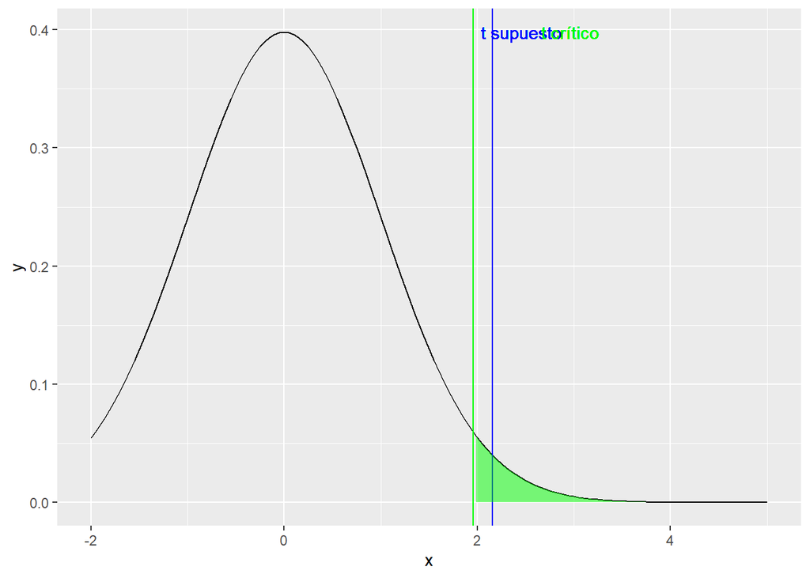

```r
data.frame(x,y) %>% ggplot(aes(x = x, y = y)) + geom_line() + geom_vline(xintercept = t_supuesto, colour = "blue") + geom_vline(xintercept = t_critico, colour = "green") + stat_function(fun = yee, geom = "area", fill = "green", alpha = 0.5) + geom_text(aes(x=t_supuesto+0.3, label="t supuesto", y=max(y)), colour="blue") + geom_text(aes(x=t_critico + 1, label="t crítico", y=max(y)), colour="green") + scale_x_continuous(limits = c(-2,5))
```

Rechazamos H0, pues como se puede ver nuestro z-crítico supuesto cae dentro de la zona de rechazo.

### Para la variable de Cantidad de bebidas

Parámetros del estudio para la variable cantidad de bebidas

Tamaño de la muestra -> 194 observaciones

Nivel de confianza -> 95%

Consideraremos que después del cuarto vaso, el alumno puede iniciar a sentir los efectos del alcohol. Tomamos una muestra de 194 alumnos y deseamos saber cuántos alumnos universitarios consumen en promedio 5 vasos o más de alcohol, con lo cual aparte de sentir los efectos del alcohol, aumenta el riesgo de padecer binge drinking.

Fuente donde se recopiló a partir de que número de vasos se considera peligroso: [NIH](https://www.niaaa.nih.gov/es/publications/el-consumo-de-alcohol-enla-universidad)

Hipótesis nula H0 -> M <= 4

Hipótesis alternativa Ha -> M > 4

Teniendo en cuenta que nuestra significancia es de 0.05.

```r
zcrit_cant <- qnorm((significancia/2), lower.tail = FALSE)
cat("Sabemos que nuestro z crítico para esta variable es", zcrit_cant )
```

```
## Sabemos que nuestro z crítico para esta variable es 1.959964
```

```r
n1 <- sum(!is.na(DF$Cantbebidas))
```

El promedio que tomamos es de 4.

```r
zcritsupuesto4 <-(mean(DF$Cantbebidas)-4)/(sd(DF$Cantbebidas)/sqrt(n1))
cat("Obtenemos que nuestro z-crítico supuesto es de", zcritsupuesto4)
```

```
## Obtenemos que nuestro z-crítico supuesto es de -0.1291856
```

```r
t_supuesto <-  zcritsupuesto4
t_critico <- zcrit_cant
x <- seq(-1,3,0.1)
y <- dt(x,100)
yee <- function(x)
{
  y <- dt(x,100)
  y[x<t_critico] <- NA
  return (y)
}
```

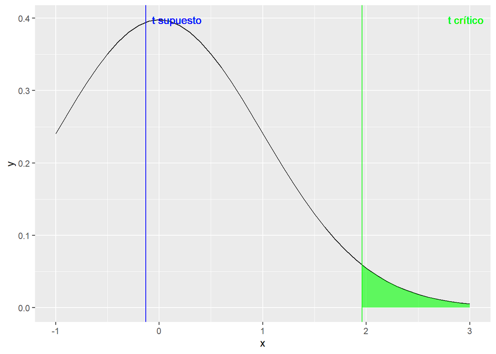

```r
data.frame(x,y) %>% ggplot(aes(x = x, y = y)) + geom_line() + geom_vline(xintercept = t_supuesto, colour = "blue") + geom_vline(xintercept = t_critico, colour = "green") + stat_function(fun = yee, geom = "area", fill = "green", alpha = 0.6) + geom_text(aes(x=t_supuesto+0.3, label="t supuesto", y=max(y)), colour="blue") + geom_text(aes(x=t_critico + 1, label="t crítico", y=max(y)), colour="green") + scale_x_continuous(limits = c(-1,3))
```

No rechazamos H0, pues como se puede ver nuestro z-crítico supuesto cae dentro de la zona no rechazo.

### Para la variable edad

Parámetros del estudio para la variable “Edad”

Tamaño de la muestra -> 194 observaciones

Nivel de confianza -> 95%

- Prueba de hipótesis

Hipótesis nula H0 -> M == 21.5

Hipótesis alternativa Ha -> M != 21.5

Teniendo en cuenta que nuestra significancia es de 0.05.

```r
zcrit_cant <- qnorm(significancia/2)
cat("Sabemos que nuestro z-crítico para esta variable es", zcrit_cant )
```

```
## Sabemos que nuestro z-crítico para esta variable es -1.959964
```

El promedio que tomamos es de 21.5

```r
mu<-21.5
zcritsupuesto19 <-(mean(DF$Edad)-mu)/(sd(DF$Edad)/sqrt(n3))
cat("Obtenemos que nuestro z-crítico supuesto es de", zcritsupuesto19)
```

```
## Obtenemos que nuestro z-crítico supuesto es de -5.269314
```

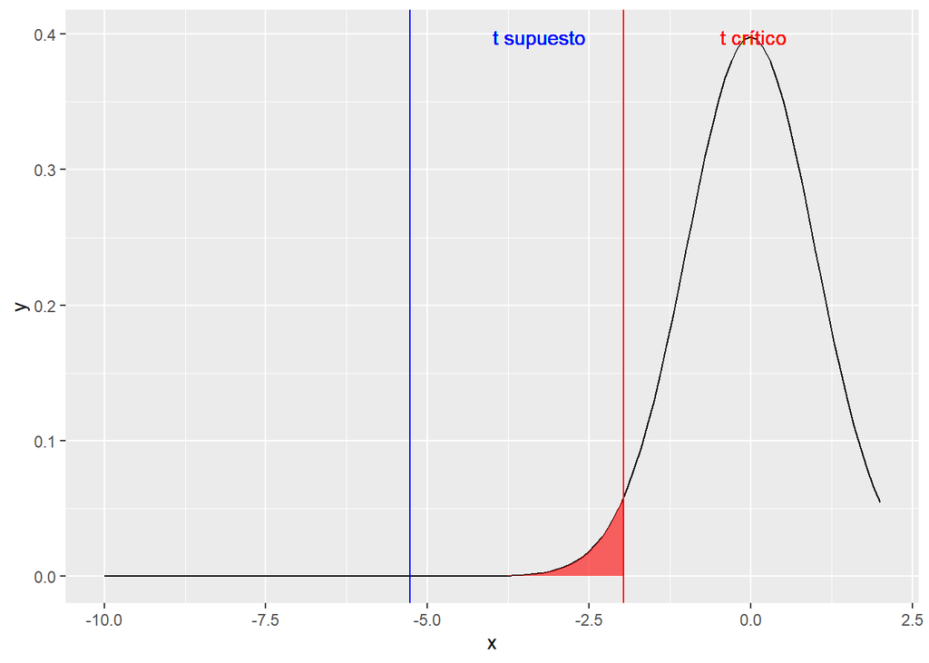

```r
t_supuesto <- zcritsupuesto19
t_critico <- zcrit_cant
x <- seq(-10,2,0.1)
y <- dt(x,100)
yee <- function(x)
{
  y <- dt(x,100)
  y[x<=t_critico] <- NA
  return (y)
}

yee2 <- function(x)
{
  y <- dt(x,100)
  y[x>=t_critico] <- NA
  return(y)

}

data.frame(x,y) %>% ggplot(aes(x = x, y = y)) + geom_line() + geom_vline(xintercept = t_supuesto, colour = "blue") + geom_vline(xintercept = t_critico, colour = "red")+  stat_function(fun=yee2, geom="area", fill="red", alpha = 0.6) + scale_x_continuous(limits = c(-10,2)) + geom_text(aes(x=t_supuesto + 2, label="t supuesto", y=max(y)), colour="blue" ) +
geom_text(aes(x=t_critico + 2, label="t crítico", y=max(y)), colour="red")
```

Rechazamos H0, pues como se puede ver nuestro z-crítico supuesto cae dentro de la zona de rechazo.

### Para la variable peso

Decidimos separar la variable peso por el género, ya que el peso es una variable que fluctúa mucho. Para disminuirlo, y considerando que, en promedio, el género masculino tiene mayor peso que el género femenino, lo dividimos para hacer el análisis correspondiente. Datos sobre el peso de hombres y mujeres en el mundo: [Altura y peso medio por país](https://www.datosmundial.com/estatura-promedio.php)

Para el caso de los hombres, tenemos 102 observaciones.

```r
DF %>%  filter(DF$Sexo == "Masculino") -> Hombre
pesohombre <- sum(!is.na(Hombre$Peso))
```

Para el caso de los mujeres, se tienen 89.

```r
DF %>%  filter(DF$Sexo == "Femenino") -> Mujer
pesomujer <-sum(!is.na(Mujer$Peso))
```

Consideraremos que para medir el grado de alcoholemia en el cuerpo se tendrá que tomar en cuenta el peso, ya que influirá para percibir los efectos del alcohol. Tomamos una muestra de 194 alumnos, los dividimos en hombres y mujeres. Los hombres tienen un peso promedio de 75Kg, mientras que las mujeres un peso de 58Kg. Deseamos saber cuántos alumnos universitarios hombres con un peso promedio mayor de 75kg pueden consumir más de 5 vasos sin que les afecte el alcohol y cuántas alumnas universitarias (mujeres) con un peso promedio mayor de 58kg pueden consumir más de 4 vasos sin que les afecte el alcohol.

En ambos casos se utilizará una prueba de hipótesis unilateral a la derecha, pues quisiéramos saber si, tanto los hombres como las mujeres, tienen un peso mayor a 75kg y 58kg respectivamente, pues serían ellos los que tendrían mayor resistencia al alcohol.

#### Hombres

Hipótesis nula H0 -> M =< 75

Hipótesis alternativa Ha -> M > 75

#### Mujeres

Hipótesis nula H0 -> M =< 58

Hipótesis alternativa Ha -> M > 58

Teniendo en cuenta que nuestra significancia es de 0.05.

```r
zcrit_cant <- qnorm((significancia/2), lower.tail = FALSE)
cat("Sabemos que nuestro zcrítico para esta variable es", zcrit_cant )
```

```
## Sabemos que nuestro zcrítico para esta variable es 1.959964
```

El promedio que tomamos para hombres es 75 Kg y para mujeres es 58 Kg.

```r
zcritsupuesto50 <-(mean(Hombre$Peso, na.rm =  T)-75)/(sd(Hombre$Peso,na.rm =  T )/sqrt(pesohombre))
cat("Obtenemos que nuestro z-crítico supuesto es de", zcritsupuesto50)
```

```
## Obtenemos que nuestro z-crítico supuesto es de -0.7880405
```

```r
zcritsupuesto500 <-(mean(Mujer$Peso, na.rm =  T)-58)/(sd(Mujer$Peso,na.rm =  T )/sqrt(pesomujer))
cat("Obtenemos que nuestro z-crítico supuesto es de", zcritsupuesto500)
```

```
## Obtenemos que nuestro z-crítico supuesto es de 3.36479
```

#### Para hombres

```r
t_supuesto <-  zcritsupuesto50
t_critico <- zcrit_cant
x <- seq(-2,5,0.05)
y <- dt(x,100)
yee <- function(x)
{
  y <- dt(x,100)
  y[x<t_critico] <- NA
  return (y)
}
```

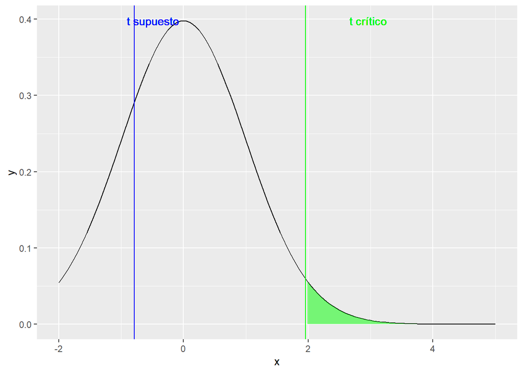

```r
data.frame(x,y) %>% ggplot(aes(x = x, y = y)) + geom_line() + geom_vline(xintercept = t_supuesto, colour = "blue") + geom_vline(xintercept = t_critico, colour = "green") + stat_function(fun = yee, geom = "area", fill = "green", alpha = 0.5) + geom_text(aes(x=t_supuesto+0.3, label="t supuesto", y=max(y)), colour="blue") + geom_text(aes(x=t_critico + 1, label="t crítico", y=max(y)), colour="green") + scale_x_continuous(limits = c(-2,5))
```

No rechazamos H0, pues como se puede ver nuestro z-crítico supuesto cae dentro de la zona de no rechazo.

#### Para Mujeres

```r
t_supuesto <-  zcritsupuesto500
t_critico <- zcrit_cant
x <- seq(-2,5,0.05)
y <- dt(x,100)
yee <- function(x)
{
  y <- dt(x,100)
  y[x<t_critico] <- NA
  return (y)
}
```

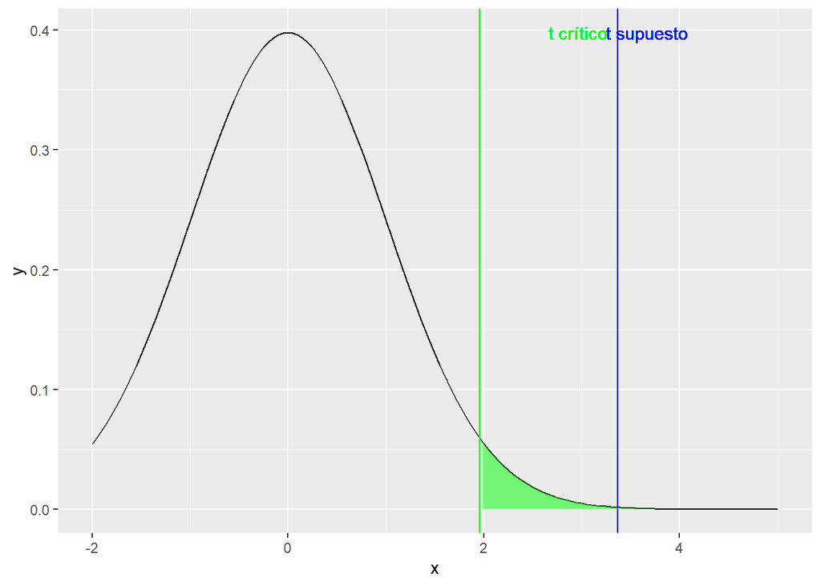

```r
data.frame(x,y) %>% ggplot(aes(x = x, y = y)) + geom_line() + geom_vline(xintercept = t_supuesto, colour = "blue") + geom_vline(xintercept = t_critico, colour = "green") + stat_function(fun = yee, geom = "area", fill = "green", alpha = 0.5) + geom_text(aes(x=t_supuesto+0.3, label="t supuesto", y=max(y)), colour="blue") + geom_text(aes(x=t_critico + 1, label="t crítico", y=max(y)), colour="green") + scale_x_continuous(limits = c(-2,5))
```

Rechazamos H0, pues como se puede ver nuestro z-crítico supuesto cae dentro de la zona de rechazo.

# Regresión

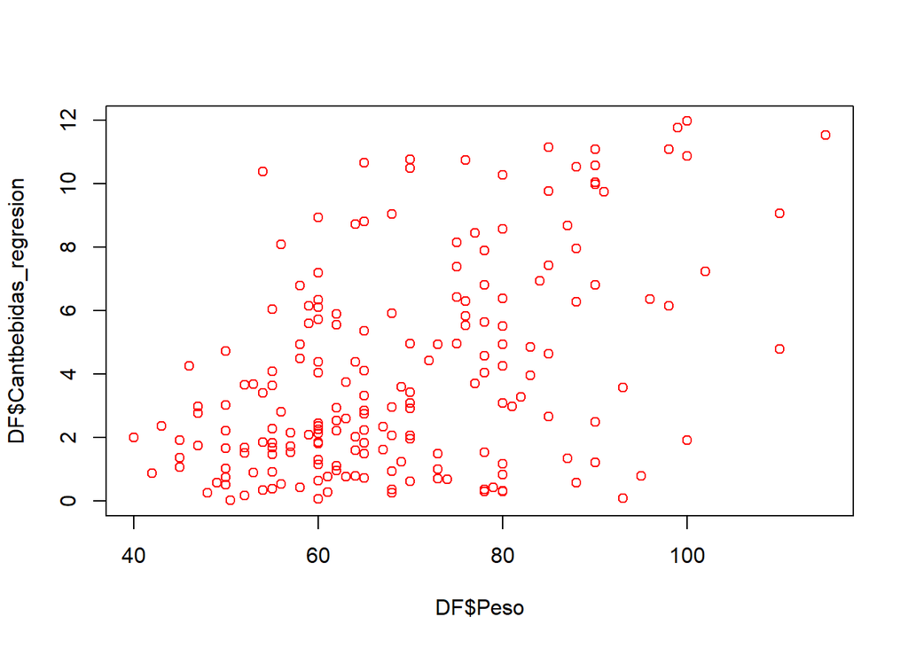

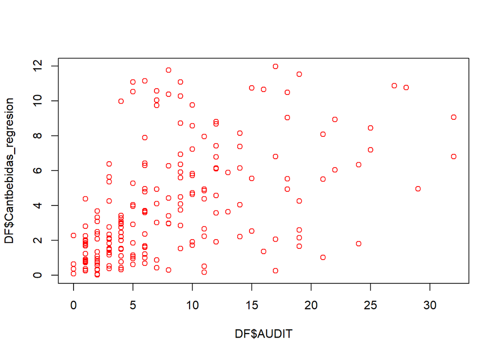

```r
plot(DF$Cantbebidas_regresion ~ DF$Peso + DF$AUDIT , col= "red")
```

```r
lm1 <- lm(DF$Cantbebidas_regresion ~ DF$Peso+DF$AUDIT)
```

### Observación:

En la limpieza de datos aleatorizamos la variable “cantidad de bebidas” debido a problemas con la discretización de la variable, la cual originalmente presentamos a los encuestados como un rango de valores según lo que consumía. La consecuencia de ello la observaremos en la gráfica de residuos.

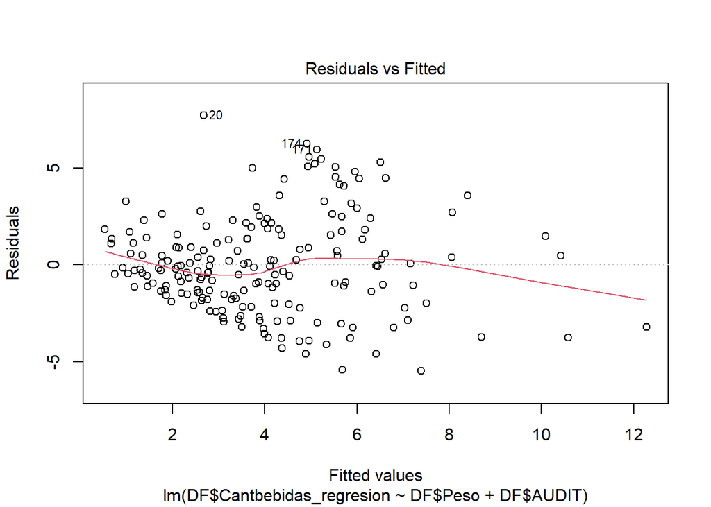

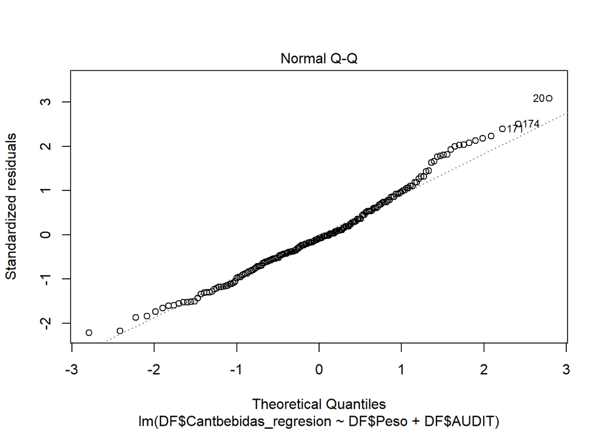

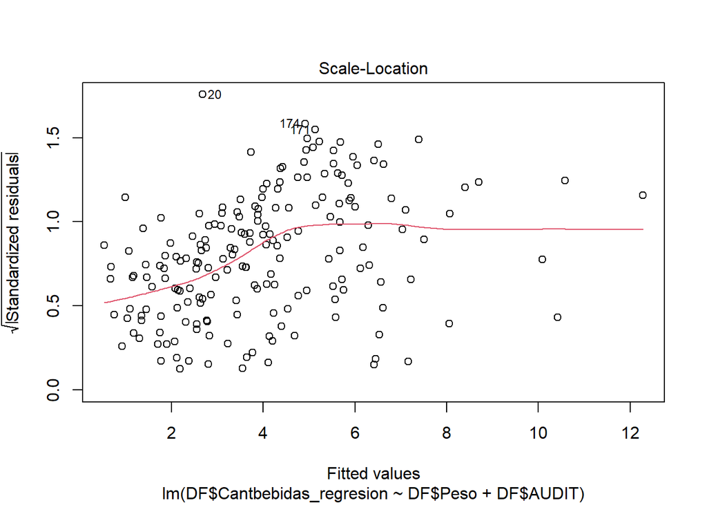

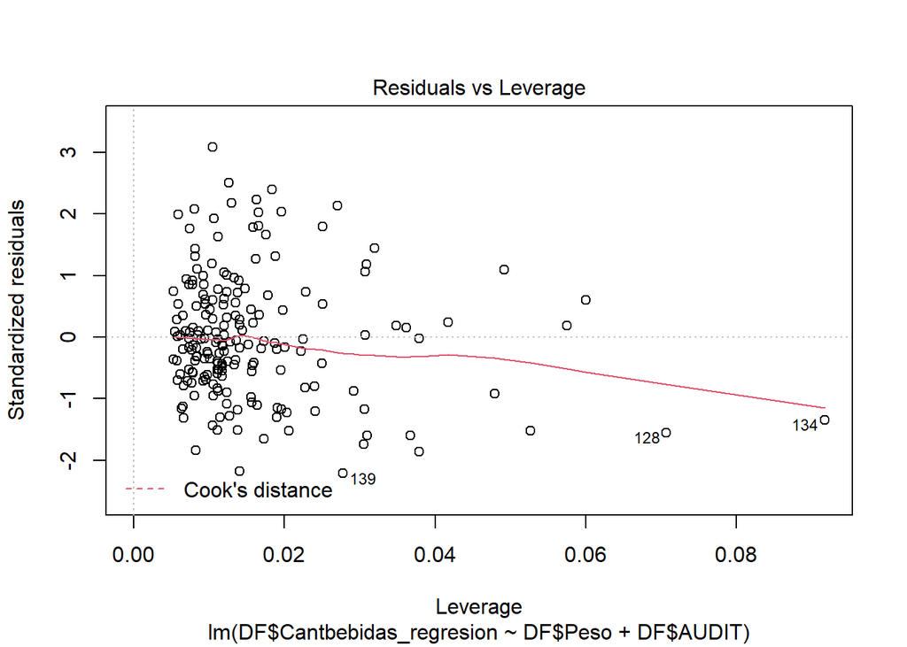

```r
plot(lm1)
```

```r
summary(lm1)
```

```
##
## Call:
## lm(formula = DF$Cantbebidas_regresion ~ DF$Peso + DF$AUDIT)
##
## Residuals:
##     Min      1Q  Median      3Q     Max
## -5.4838 -1.5986 -0.2067  1.4892  7.7074
##
## Coefficients:
##             Estimate Std. Error t value Pr(>|t|)
## (Intercept) -3.52882    0.85626  -4.121 5.65e-05 ***
## DF$Peso      0.08504    0.01229   6.922 6.80e-11 ***
## DF$AUDIT     0.20156    0.02678   7.527 2.10e-12 ***
## ---
## Signif. codes:  0 '***' 0.001 '**' 0.01 '*' 0.05 '.' 0.1 ' ' 1
##
## Residual standard error: 2.511 on 188 degrees of freedom
##   (3 observations deleted due to missingness)
## Multiple R-squared:  0.4031, Adjusted R-squared:  0.3967
## F-statistic: 63.48 on 2 and 188 DF,  p-value: < 2.2e-16
```

## Análisis de la gráfica de residuos

Podemos observar en la gráfica de residuos de la relación planteada que hay un problema de **heterocedasticidad**, la cual implica una varianza de errores que no es constante. Es por eso que en la gráfica de residuos, la parte de la izquierda parece haber una poca variación de los errores o residuos, mientras que en la parte del centro hay una mayor variación. Esto es un problema ya que se pierde eficiencia en las tendencias y predicciones (análisis inferencial).

## Análisis descriptivo

# Conclusiones

## ¿Hay una relación entre el estrés académico y el binge drinking en jóvenes universitarios?

En base al estudio estadístico que realizamos en jóvenes estudiantes entre los 17 y 26 aproximadamente, pudimos notar los siguiente:

- Como era de esperarse, la dificultad del ciclo aumenta de acuerdo a la cantidad de créditos que el estudiante lleve. Sin embargo, no encontramos relación entre el riesgo de padecer Binge Drinking y la percepción de dificultad del ciclo o la cantidad de créditos del alumno.
- Por otro lado, hallamos algo interesante respecto al género. Los hombres son más propensos a padecer Binge Drinking que las mujeres. Esto se debe a que suelen consumir más vasos cuando beben y bebidas con un mayor porcentaje de alcohol.
- Se intentó encontrar una relación entre el número de bebidas que consume en una ocasión el alumno y el número de exámenes que ha jalado durante el ciclo, interpretando esta relación como una forma de medir el estrés académico del alumno y su riesgo a padecer Binge Drinking, pero las variables no estaban relacionadas.
- Ocurrió lo mismo con la prueba del porcentaje de las bebidas que el alumno suele consumir, con la cantidad de créditos que se llevan en el ciclo. Inicialmente se pensaba que habría una relación, y el alumno tomaría más si está llevando una mayor cantidad de créditos, pero nuevamente las variables no estaban relacionadas.

Nuestra hipótesis inicial era que había una relación positiva entre el estrés académico de un estudiante y el padecimiento de Binge Drinking. Sin embargo, no se ha podido a reunir evidencias suficientes. En nuestro estudio, se ha concluido que el estrés académico no se relaciona, ni positiva ni negativamente, con el padecimiento de Binge Drinking. Esto podría deberse a que existen variables que no hemos incluido en nuestra encuesta y no hemos podido cuantificarlas, o que al ser una investigación de menor escala, con menos de 200 observaciones, contamos con poca información para hacer conclusiones mayores, pero es a lo que se ha podido llegar con este informe.

# Bibliografía

https://idus.us.es/bitstream/handle/11441/12812/file_1.pdf https://www.who.int/publications/i/item/9789241565639 https://www.madridsalud.es/serviciopad/binge-drinking-los-riesgos-del-peligroso-consumo-por-atracon-en-adolescentes-y-jovenes/ https://www.sciencedirect.com/science/article/abs/pii/S0306460311003169 https://www.drugabuse.gov/sites/default/files/audit.pdf https://auditscreen.org/about/audit-decision-tree/ https://www.cdc.gov/alcohol/fact-sheets/binge-drinking.htm#:~:text=Binge%20drinking%20is%20a%20serious%20but%20preventable%20public%20health%20problem,use%20in%20the%20United%20States.&text=Binge%20drinking%20is%20defined%20as,0.08%20g%2Fdl%20or%20above. https://d1wqtxts1xzle7.cloudfront.net/53585384/0000_M_ALCOHOL_Y_SALUD_EPUB-with-cover-page-v2.pdf?Expires=1633227403&Signature=MtU5VWdexXCOjvrKLDIECANTNCGkkt9iejsSYn-02E9AOTDPFxRC1ZMRxPjBnVHJszjgUIRx4HTGds-nTQymAhReikkI9nkngyKWnjKjmhEHfUhKDQtbGYkzlMcnvwaVhcAlenOwoW54hFNiQ0wE1OliZubt-HejcYNxSDFRfoDPPNcZWO557mCnJHfqjRoEwALtYiFnpETEZ1fq~jV3HB0fTo0bFILqni8-1zeANZGy0oFbAdpRD9hApoMSM08YqVSlM6MmPs95buu7jgl5Ape4mAZHoSHzfnOIhTlWaQYvs6flMdEI5RDbf1ZigX9rMdBNzSzTwFPM5BxOq2YxHQ__&Key-Pair-Id=APKAJLOHF5GGSLRBV4ZA